# Analisis funcional para hongos

# introduccion

Desafortunadamente, metagenassist solo funcion paras las asignacion funcional de fenotipos en bacterias por lo que para hongos usaremos la base de datos FungalTraits que es una base de datos de rasgos de hongos acoplada para ser usada en RStudio. La base fue creada combianando informacion de bases previas conocidad como FUNGuild y fUN LAS CUALES USAN informacion de unite respecto a caracterisiticas fenotipicas de cientos de secuencias de hongos a nivel de genero y especie

```r
library(ggsignif)
```

```r
FT <- fungi_func_FungalTraits # de datos suplementarios
```

```
Error: objeto 'fungi_func_FungalTraits' no encontrado
```

# Asignacion de grupos funcionales

en este caso el proeso de asignacion va ser manual usando el codigo de R merge(), para ello se usa una variable comin entre dos tablas y la mas especifica es genero:

```r
Fun_fun <- Fun_fun[,-[,-6]
```

```
Error: inesperado '[' en "Fun_fun <- Fun_fun[,-["
```

```r
Fun_counts %>%
  mutate(soilsapro_sum = colSums(across(c(1:20))))
```

[output not shown]

## Preprocesamiento de datos

```r
Sim_fungi <- Sim_fungi[ , sorder]
```

```
Error: objeto 'sorder' no encontrado
```

## Grafico

[figure not shown]

# Grupos especificos

Si bien recuerdan FungalTraits nos da un estilo de vida primario (que es el que usamos hace rato para el heatmap) pero tambien definio algunas de las especies con un estilo de vida secundario. Uno de estos grupos dentro de esta categoria es especies asociadas a raices (root-associated) usando esa clasificacion, graficaremos los hongos que ya han sido especificamente clasificados como habitantes de la rizosfera:

### preprocesamiento : root associated

```r
conames(Func_fungi) <- Func_fungi[1,]
```

```
Error in conames(Func_fungi) <- Func_fungi[1, ] :
  no se pudo encontrar la función "conames<-"
```

# Boxplot

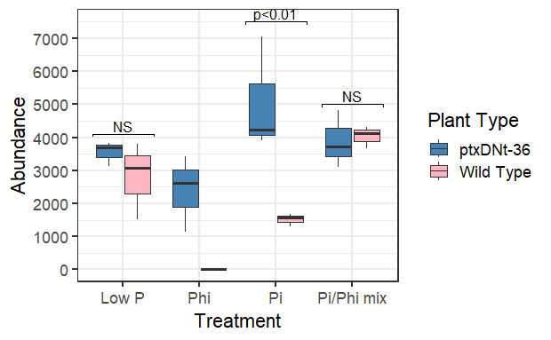